# Using ‘dollar per offer’ to identify opportunities for increased investment

8/16/2019

## Overview

## What are we examining?

- 14 products
- 4 sales channels
- 4 divisions
- Data provided on:
  - number of units offered
  - number of units sold
  - total revenue earned

## Changes over time

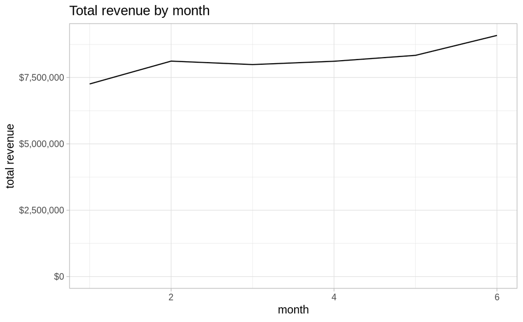

## How should we evaluate the success of sales?

## Success rate

- Sale rate is consistent across division, product, channel, month
- Accross all variables, .3% of products offered are sold

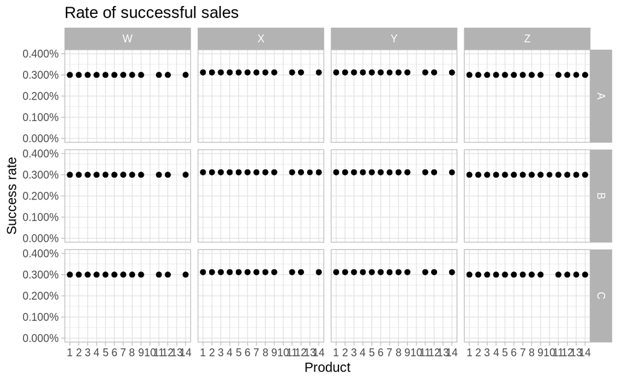

## Average sale

- Revenue per sale driven mostly by product
- Consistent across month and division

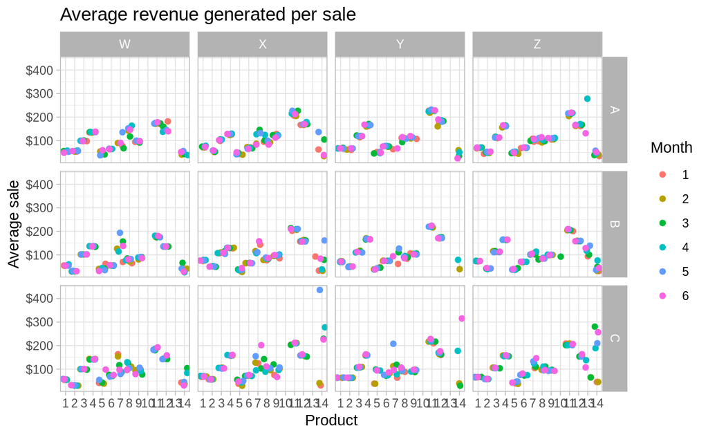

## Dollar earned per offer

- Closest possible to a ‘return on investment’ with the data available
- Will use this for remainder of presentation

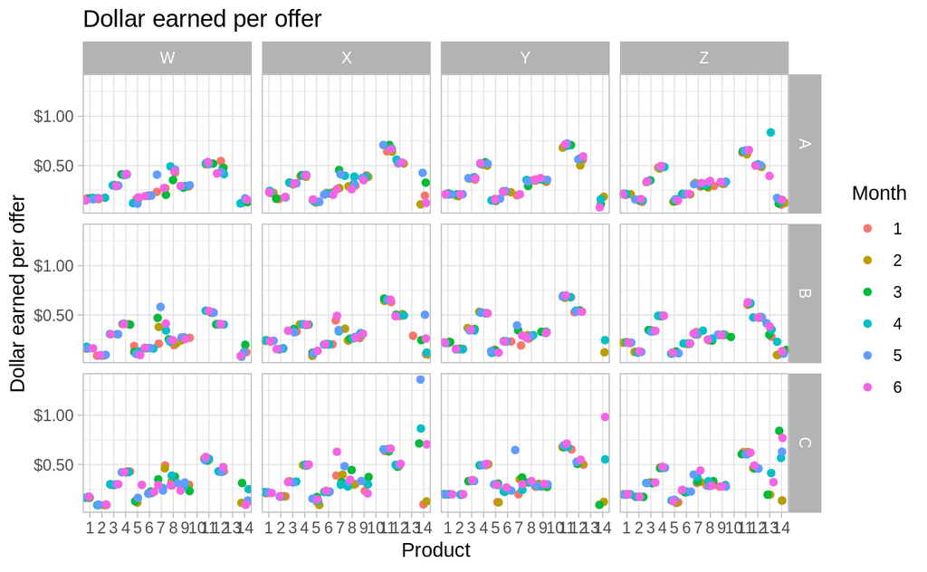

## More about dollar per offer

- In practice, will resemble average sale for this analysis because the sale success rate is so steady across all variables
- This metric will be more flexible if / when success rate changes
  - Incoroprates cost which average sale cannot
- Ideally, future analyses examine individual level information to understand lifetime value of customers in realtionship to the investment required to make the sale
- However, this assumes a consistent cost to offer across products, divisions, and channels
  - If costs of offer vary substantially, this analysis can be adapted by adding / estimating those costs
- May be useful for identifying opportunities for increased investment or finding most efficient products / channels / divisions

## What influences dollar per offer?

## Predicting dollar per offer

- I built two statistical models with four sets of variables each
- Product and sales channel provide most helpful information in predicting dollar per offer

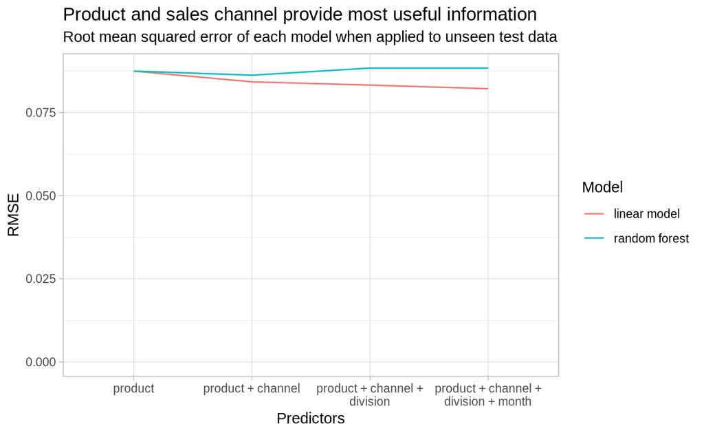

## What are the most profitable products?

## Most revenue driven by a few products

- Products 3 and 4 are the highest selling, offered most
- Channels Z and X generate the most revenue

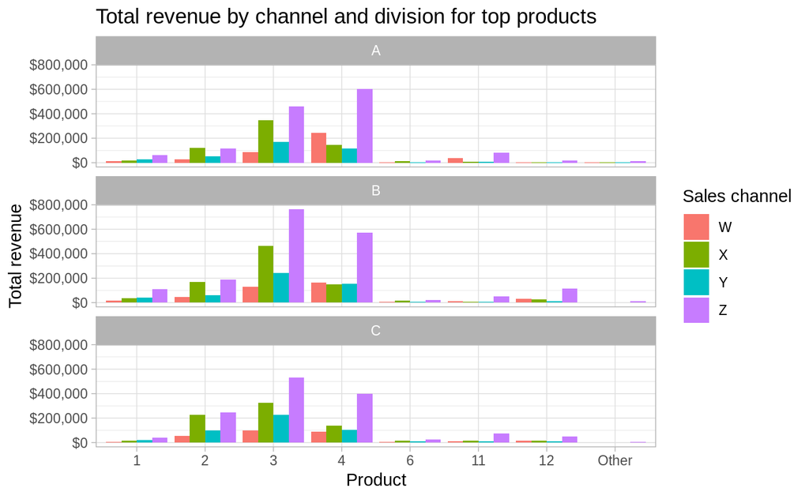

## Revenue vs efficiency

- Channel Y tends to offer a higher return on investment
- Products 11 and 12 also have a higher dollar per offer but generate fairly low amounts of revenue

[figure not shown]

## Outstanding questions

- What is the cost of each offer? Is it consistent or variable?
  - If variable, need to incorporate this information before making recommendations
- Why is success rate so consistent?
- Conduct deeper analysis using individual level information about customers
  - What does it cost to acquire a customer?
  - Can we predict a customer’s lifetime value?
  - Do some products / channels / divisions have better customer retention?